# Census Shenanigans

Ethan Crookshank

Loading all of the packages that we need and using the API key to fetch census data

```r
# packages
library(tidyverse)
library(tidycensus)
library(sf)
library(ggplot2)

# settings for tidycensus
options(tigris_class = "sf")
options(tigris_use_cache = TRUE)
census_api_key("937eed644b7bc41f3ae13d18f51a459a4ac85100")
```

```
To install your API key for use in future sessions, run this function with `install = TRUE`.
```

Alright, every single chunk after this does the Same. Exact. Thing.

First, we assign the 2019 data for average weekly hours worked in Maryland to the conveniently named mean_work_hours_2019 variable.

Next, we map it, because I was going to be ambitious and try to fulfill the “make a really good map with ggplots” challenge before my other classes clotheslined me, and I never took this line out. Post-hoc, it’s probably good to make sure that it’s actually plotting the data that you think should be in there.

We then convert to Mercator after plotting to prove that these ideas occurred to me at entirely different points in time.

Finally we write this data to a shapefile that we can load later in qgis or arcmap.

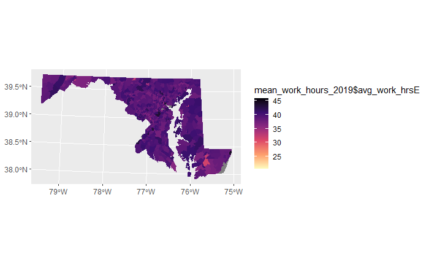

```r
mean_work_hours_2019 <- get_acs(geography = "tract",
     variables = c("avg_work_hrs"="B23020_001"),
     year = 2019,
     survey = "acs5",
     state =" MD",

     geometry = TRUE, # download the shapefile with the data
     output = "wide") # need this
mean_work_hours_2019 %>% ggplot(aes(fill=mean_work_hours_2019$avg_work_hrsE, color=mean_work_hours_2019$avg_work_hrsE))+
  geom_sf() +
  coord_sf(crs=26918) + # Web Mercator 3857, or UTM 18N for Maryland 26918
  scale_fill_viridis_c(option="magma", direction=-1) +
  scale_color_viridis_c(option="magma", direction=-1)
```

```r
mean_work_hours_2019 <- st_transform(mean_work_hours_2019, 3857)


st_write(mean_work_hours_2019,  "MD_Mean_Work_Hours_2019.shp", update= T)
```

```
'update' is deprecated.
Use 'append' instead.
See help("Deprecated")Field names abbreviated for ESRI Shapefile driver
```

```
Updating layer `MD_Mean_Work_Hours_2019' to data source `MD_Mean_Work_Hours_2019.shp' using driver `ESRI Shapefile'
Updating existing layer MD_Mean_Work_Hours_2019
Writing 1406 features with 4 fields and geometry type Multi Polygon.
```

Same as above but for 2018

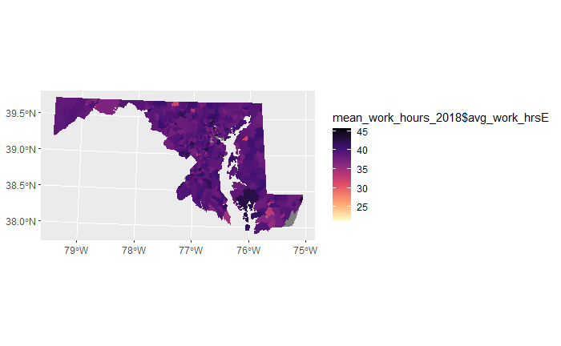

```r
mean_work_hours_2018 <- get_acs(geography = "tract",
     variables = c("avg_work_hrs"="B23020_001"),
     year = 2018,
     survey = "acs5",
     state =" MD",

     geometry = TRUE, # download the shapefile with the data
     output = "wide") # need this
mean_work_hours_2018 %>% ggplot(aes(fill=mean_work_hours_2018$avg_work_hrsE, color=mean_work_hours_2018$avg_work_hrsE))+
  geom_sf() +
  coord_sf(crs=26918) + # Web Mercator 3857, or UTM 18N for Maryland 26918
  scale_fill_viridis_c(option="magma", direction=-1) +
  scale_color_viridis_c(option="magma", direction=-1)
```

```r
mean_work_hours_2018 <- st_transform(mean_work_hours_2018, 3857)


st_write(mean_work_hours_2018,  "MD_Mean_Work_Hours_2018.shp", update= T)
```

```
'update' is deprecated.
Use 'append' instead.
See help("Deprecated")Field names abbreviated for ESRI Shapefile driver
```

```
Updating layer `MD_Mean_Work_Hours_2018' to data source `MD_Mean_Work_Hours_2018.shp' using driver `ESRI Shapefile'
Updating existing layer MD_Mean_Work_Hours_2018
Writing 1406 features with 4 fields and geometry type Multi Polygon.
```

Next up is 2017

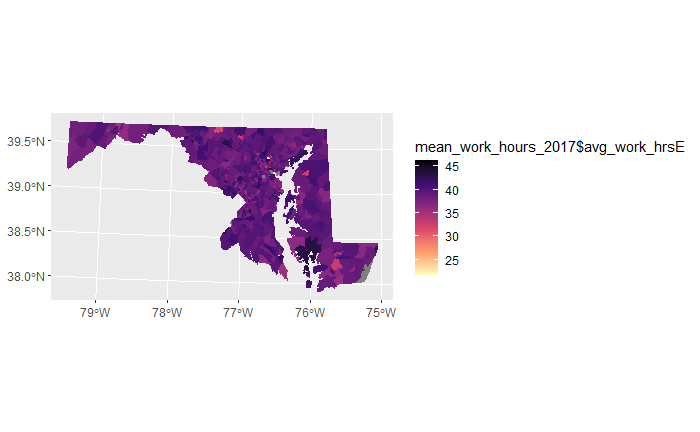

```r
mean_work_hours_2017 <- get_acs(geography = "tract",
     variables = c("avg_work_hrs"="B23020_001"),
     year = 2017,
     survey = "acs5",
     state =" MD",

     geometry = TRUE, # download the shapefile with the data
     output = "wide") # need this
mean_work_hours_2017 %>% ggplot(aes(fill=mean_work_hours_2017$avg_work_hrsE, color=mean_work_hours_2017$avg_work_hrsE))+
  geom_sf() +
  coord_sf(crs=26918) + # Web Mercator 3857, or UTM 18N for Maryland 26918
  scale_fill_viridis_c(option="magma", direction=-1) +
  scale_color_viridis_c(option="magma", direction=-1)
```

```r
mean_work_hours_2017 <- st_transform(mean_work_hours_2017, 3857)


st_write(mean_work_hours_2017,  "MD_Mean_Work_Hours_2017.shp", update= T)
```

```
'update' is deprecated.
Use 'append' instead.
See help("Deprecated")Field names abbreviated for ESRI Shapefile driver
```

```
Updating layer `MD_Mean_Work_Hours_2017' to data source `MD_Mean_Work_Hours_2017.shp' using driver `ESRI Shapefile'
Updating existing layer MD_Mean_Work_Hours_2017
Writing 1406 features with 4 fields and geometry type Multi Polygon.
```

And now 2016

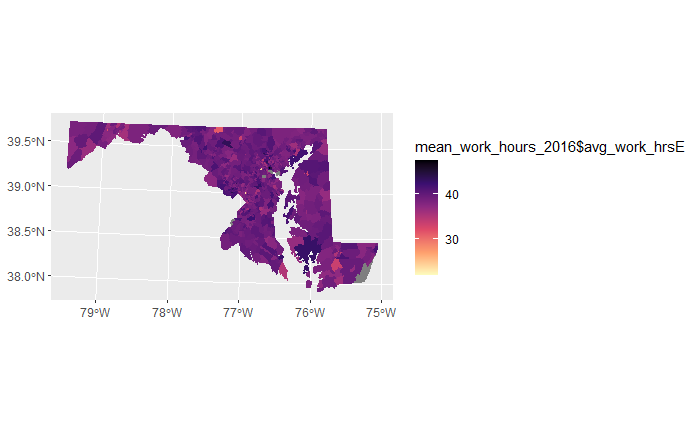

```r
mean_work_hours_2016 <- get_acs(geography = "tract",
     variables = c("avg_work_hrs"="B23020_001"),
     year = 2016,
     survey = "acs5",
     state =" MD",

     geometry = TRUE, # download the shapefile with the data
     output = "wide") # need this
mean_work_hours_2016 %>% ggplot(aes(fill=mean_work_hours_2016$avg_work_hrsE, color=mean_work_hours_2016$avg_work_hrsE))+
  geom_sf() +
  coord_sf(crs=26918) + # Web Mercator 3857, or UTM 18N for Maryland 26918
  scale_fill_viridis_c(option="magma", direction=-1) +
  scale_color_viridis_c(option="magma", direction=-1)
```

```r
mean_work_hours_2016 <- st_transform(mean_work_hours_2016, 3857)


st_write(mean_work_hours_2016,  "MD_Mean_Work_Hours_2016.shp", update= T)
```

```
'update' is deprecated.
Use 'append' instead.
See help("Deprecated")Field names abbreviated for ESRI Shapefile driver
```

```
Updating layer `MD_Mean_Work_Hours_2016' to data source `MD_Mean_Work_Hours_2016.shp' using driver `ESRI Shapefile'
Updating existing layer MD_Mean_Work_Hours_2016
Writing 1406 features with 4 fields and geometry type Multi Polygon.
```

I’m not too good at math but I think 2015 comes next

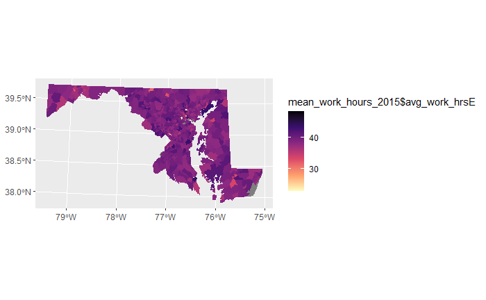

```r
mean_work_hours_2015 <- get_acs(geography = "tract",
     variables = c("avg_work_hrs"="B23020_001"),
     year = 2015,
     survey = "acs5",
     state =" MD",

     geometry = TRUE, # download the shapefile with the data
     output = "wide") # need this
mean_work_hours_2015 %>% ggplot(aes(fill=mean_work_hours_2015$avg_work_hrsE, color=mean_work_hours_2015$avg_work_hrsE))+
  geom_sf() +
  coord_sf(crs=26918) + # Web Mercator 3857, or UTM 18N for Maryland 26918
  scale_fill_viridis_c(option="magma", direction=-1) +
  scale_color_viridis_c(option="magma", direction=-1)
```

```r
mean_work_hours_2015 <- st_transform(mean_work_hours_2015, 3857)


st_write(mean_work_hours_2015,  "MD_Mean_Work_Hours_2015.shp", update= T)
```

```
'update' is deprecated.
Use 'append' instead.
See help("Deprecated")Field names abbreviated for ESRI Shapefile driver
```

```
Updating layer `MD_Mean_Work_Hours_2015' to data source `MD_Mean_Work_Hours_2015.shp' using driver `ESRI Shapefile'
Updating existing layer MD_Mean_Work_Hours_2015
Writing 1406 features with 4 fields and geometry type Multi Polygon.
```

On to 2014

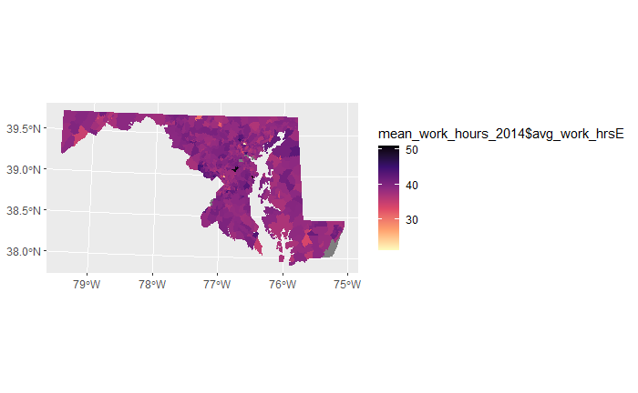

```r
mean_work_hours_2014 <- get_acs(geography = "tract",
     variables = c("avg_work_hrs"="B23020_001"),
     year = 2014,
     survey = "acs5",
     state =" MD",

     geometry = TRUE, # download the shapefile with the data
     output = "wide") # need this
mean_work_hours_2014 %>% ggplot(aes(fill=mean_work_hours_2014$avg_work_hrsE, color=mean_work_hours_2014$avg_work_hrsE))+
  geom_sf() +
  coord_sf(crs=26918) + # Web Mercator 3857, or UTM 18N for Maryland 26918
  scale_fill_viridis_c(option="magma", direction=-1) +
  scale_color_viridis_c(option="magma", direction=-1)
```

```r
mean_work_hours_2014 <- st_transform(mean_work_hours_2014, 3857)


st_write(mean_work_hours_2014,  "MD_Mean_Work_Hours_2014.shp", update= T)
```

```
'update' is deprecated.
Use 'append' instead.
See help("Deprecated")Field names abbreviated for ESRI Shapefile driver
```

```
Updating layer `MD_Mean_Work_Hours_2014' to data source `MD_Mean_Work_Hours_2014.shp' using driver `ESRI Shapefile'
Updating existing layer MD_Mean_Work_Hours_2014
Writing 1406 features with 4 fields and geometry type Multi Polygon.
```

2013, no fuss no muss

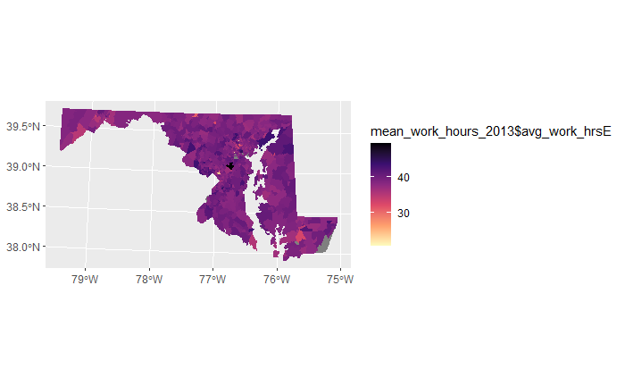

```r
mean_work_hours_2013 <- get_acs(geography = "tract",
     variables = c("avg_work_hrs"="B23020_001"),
     year = 2013,
     survey = "acs5",
     state =" MD",

     geometry = TRUE, # download the shapefile with the data
     output = "wide") # need this
mean_work_hours_2013 %>% ggplot(aes(fill=mean_work_hours_2013$avg_work_hrsE, color=mean_work_hours_2013$avg_work_hrsE))+
  geom_sf() +
  coord_sf(crs=26918) + # Web Mercator 3857, or UTM 18N for Maryland 26918
  scale_fill_viridis_c(option="magma", direction=-1) +
  scale_color_viridis_c(option="magma", direction=-1)
```

```r
mean_work_hours_2013 <- st_transform(mean_work_hours_2013, 3857)


st_write(mean_work_hours_2013,  "MD_Mean_Work_Hours_2013.shp", update= T)
```

```
'update' is deprecated.
Use 'append' instead.
See help("Deprecated")Field names abbreviated for ESRI Shapefile driver
```

```
Updating layer `MD_Mean_Work_Hours_2013' to data source `MD_Mean_Work_Hours_2013.shp' using driver `ESRI Shapefile'
Updating existing layer MD_Mean_Work_Hours_2013
Writing 1406 features with 4 fields and geometry type Multi Polygon.
```

2012, when the world was supposed to end

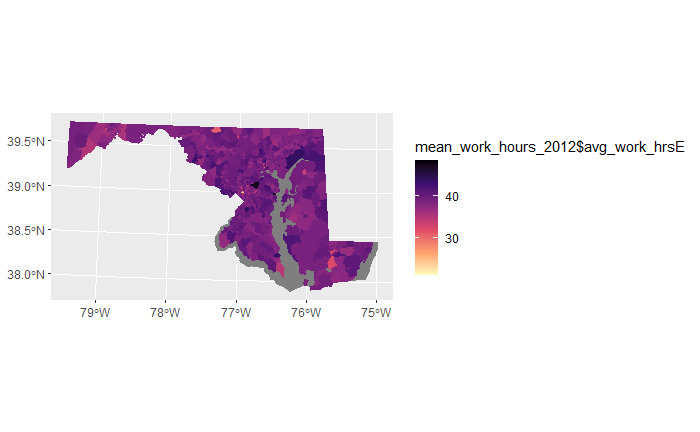

```r
mean_work_hours_2012 <- get_acs(geography = "tract",
     variables = c("avg_work_hrs"="B23020_001"),
     year = 2012,
     survey = "acs5",
     state =" MD",

     geometry = TRUE, # download the shapefile with the data
     output = "wide") # need this
mean_work_hours_2012 %>% ggplot(aes(fill=mean_work_hours_2012$avg_work_hrsE, color=mean_work_hours_2012$avg_work_hrsE))+
  geom_sf() +
  coord_sf(crs=26918) + # Web Mercator 3857, or UTM 18N for Maryland 26918
  scale_fill_viridis_c(option="magma", direction=-1) +
  scale_color_viridis_c(option="magma", direction=-1)
```

```r
mean_work_hours_2012 <- st_transform(mean_work_hours_2012, 3857)


st_write(mean_work_hours_2012,  "MD_Mean_Work_Hours_2012.shp", update= T)
```

```
'update' is deprecated.
Use 'append' instead.
See help("Deprecated")Field names abbreviated for ESRI Shapefile driver
```

```
Updating layer `MD_Mean_Work_Hours_2012' to data source `MD_Mean_Work_Hours_2012.shp' using driver `ESRI Shapefile'
Updating existing layer MD_Mean_Work_Hours_2012
Writing 1406 features with 4 fields and geometry type Multi Polygon.
```

I bet 2011 is next

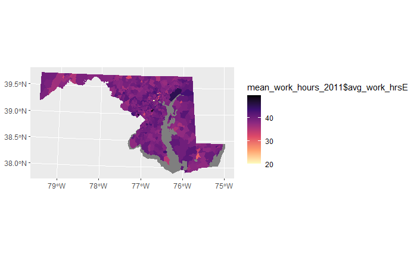

```r
mean_work_hours_2011 <- get_acs(geography = "tract",
     variables = c("avg_work_hrs"="B23020_001"),
     year = 2011,
     survey = "acs5",
     state =" MD",

     geometry = TRUE, # download the shapefile with the data
     output = "wide") # need this
mean_work_hours_2011 %>% ggplot(aes(fill=mean_work_hours_2011$avg_work_hrsE, color=mean_work_hours_2011$avg_work_hrsE))+
  geom_sf() +
  coord_sf(crs=26918) + # Web Mercator 3857, or UTM 18N for Maryland 26918
  scale_fill_viridis_c(option="magma", direction=-1) +
  scale_color_viridis_c(option="magma", direction=-1)
```

```r
mean_work_hours_2011 <- st_transform(mean_work_hours_2011, 3857)


st_write(mean_work_hours_2011,  "MD_Mean_Work_Hours_2011.shp", update= T)
```

```
'update' is deprecated.
Use 'append' instead.
See help("Deprecated")Field names abbreviated for ESRI Shapefile driver
```

```
Updating layer `MD_Mean_Work_Hours_2011' to data source `MD_Mean_Work_Hours_2011.shp' using driver `ESRI Shapefile'
Updating existing layer MD_Mean_Work_Hours_2011
Writing 1406 features with 4 fields and geometry type Polygon.
```

And finally 2010, because that’s as far back as this data was available for!

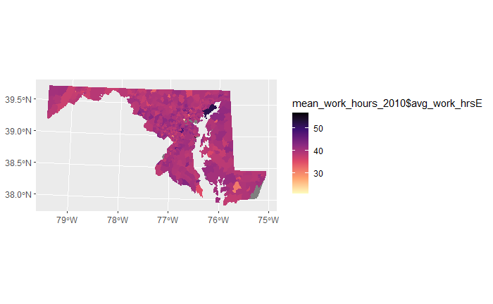

```r
mean_work_hours_2010 <- get_acs(geography = "tract",
     variables = c("avg_work_hrs"="B23020_001"),
     year = 2010,
     survey = "acs5",
     state =" MD",

     geometry = TRUE, # download the shapefile with the data
     output = "wide") # need this
mean_work_hours_2010 %>% ggplot(aes(fill=mean_work_hours_2010$avg_work_hrsE, color=mean_work_hours_2010$avg_work_hrsE))+
  geom_sf() +
  coord_sf(crs=26918) + # Web Mercator 3857, or UTM 18N for Maryland 26918
  scale_fill_viridis_c(option="magma", direction=-1) +
  scale_color_viridis_c(option="magma", direction=-1)
```

```r
mean_work_hours_2010 <- st_transform(mean_work_hours_2010, 3857)


st_write(mean_work_hours_2010,  "MD_Mean_Work_Hours_2010.shp", update= T)
```

```
'update' is deprecated.
Use 'append' instead.
See help("Deprecated")Field names abbreviated for ESRI Shapefile driver
```

```
Updating layer `MD_Mean_Work_Hours_2010' to data source `MD_Mean_Work_Hours_2010.shp' using driver `ESRI Shapefile'
Writing 1406 features with 4 fields and geometry type Multi Polygon.
```